# Weather Case Study

We will analyse the weather data and find the linear relationship between Temperature and other factors of weather.

### Read and Understand the dataset

```python
# Import necessary Libraries
# Libraries to help with reading and manipulating data
import pandas as pd
import numpy as np

# Libraries to help with data visualization
import matplotlib.pyplot as plt
import seaborn as sns
# sns.set() will load seaborn's default theme and color palette to the session.
sns.set()

# split the data into train and test
from sklearn.model_selection import train_test_split

# to built linear regression_model using statsmodels
import statsmodels.api as sm

# to check model performance
from sklearn.metrics import mean_squared_error, mean_absolute_error, r2_score
```

```python
from google.colab import drive
drive.mount('/content/drive')
```

```python
# Read the dataset
df = pd.read_csv("/content/drive/My Drive/tasha/weather.csv")
```

## Data Overview:

Please check the fillowings;

- Shape of the dataset
- First and last 5 data points
- Check data types
- Get summary statistics

```python
#check the shape of the data set
df.shape
```

```
(10000, 8)
```

```python
# Observe first and last 5 data points
print(df.head(5))
print('-----')
print(df.tail(5))
```

```
   Temperature_c  Humidity  Wind_Speed_kmh  Wind_Bearing_degrees  \
0      -0.555556      0.92         11.2700                   130
1      21.111111      0.73         20.9300                   330
2      16.600000      0.97          5.9731                   193
3       1.600000      0.82          3.2200                   300
4       2.194444      0.60         10.8836                   116

   Visibility_km  Pressure_millibars  Rain Description
0         8.0500             1021.60     0        Cold
1        16.1000             1017.00     1        Warm
2        14.9086             1013.99     1      Normal
3        16.1000             1031.59     1        Cold
4         9.9820             1020.88     1        Cold
-----
      Temperature_c  Humidity  Wind_Speed_kmh  Wind_Bearing_degrees  \
9995      10.022222      0.95         10.2396                    20
9996       8.633333      0.64         11.0446                    80
9997       5.977778      0.93         11.0446                   269
9998       9.788889      0.78          8.1788                   231
9999      11.138889      0.79         14.2485                   131

      Visibility_km  Pressure_millibars  Rain Description
9995         4.0089             1007.41     1      Normal
9996         9.9820             1031.33     1      Normal
9997        14.9086             1014.21     1      Normal
9998         7.8246             1005.02     1      Normal
9999        10.2557             1010.14     1      Normal
```

This data appears to be weather observations, with parameters like temperature, humidity, and wind speed.

```python
# Check the datatypes
print(df.dtypes)
```

```
Temperature_c           float64
Humidity                float64
Wind_Speed_kmh          float64
Wind_Bearing_degrees      int64
Visibility_km           float64
Pressure_millibars      float64
Rain                      int64
Description              object
dtype: object
```

```python
# Get the statistical summary of the numerical variables
print(df.describe())
```

```
       Temperature_c      Humidity  Wind_Speed_kmh  Wind_Bearing_degrees  \
count   10000.000000  10000.000000    10000.000000          10000.000000
mean       11.857208      0.735272       10.813565            185.979700
std         9.512244      0.195498        6.972569            107.469909
min       -21.822222      0.000000        0.000000              0.000000
25%         4.655556      0.600000        5.747700            112.000000
50%        11.561111      0.780000        9.933700            179.000000
75%        18.822222      0.900000       14.103600            290.000000
max        38.838889      1.000000       53.242700            359.000000

       Visibility_km  Pressure_millibars          Rain
count   10000.000000        10000.000000  10000.000000
mean       10.372964         1004.896421      0.891200
std         4.178680          109.617120      0.311404
min         0.000000            0.000000      0.000000
25%         8.287475         1011.890000      1.000000
50%        10.046400         1016.500000      1.000000
75%        14.876400         1021.110000      1.000000
max        16.100000         1045.380000      1.000000
```

### EDA

#### Univariate Analysis

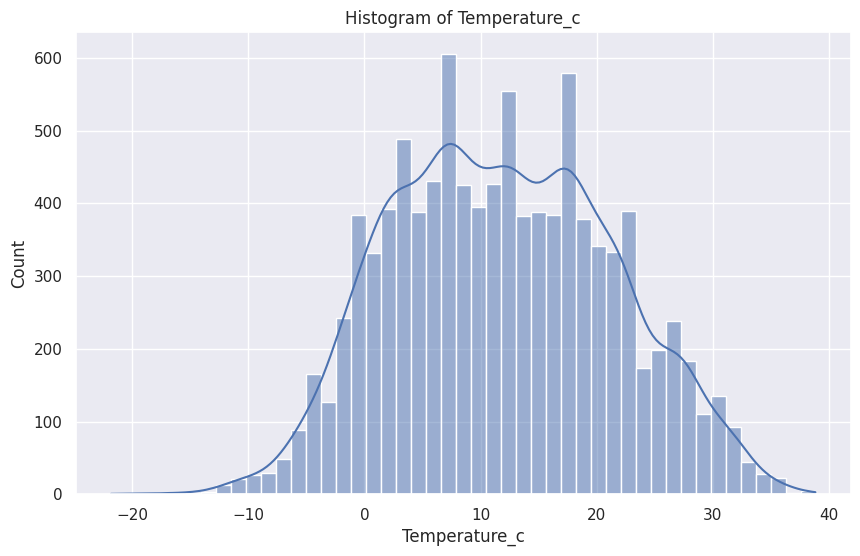

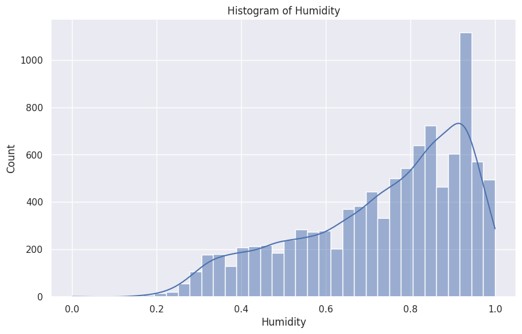

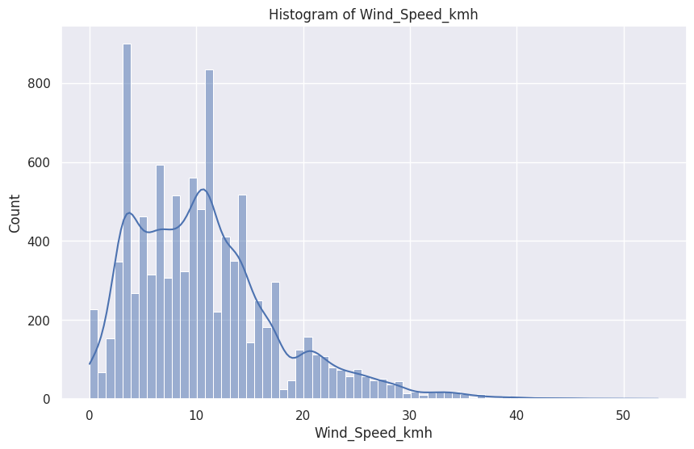

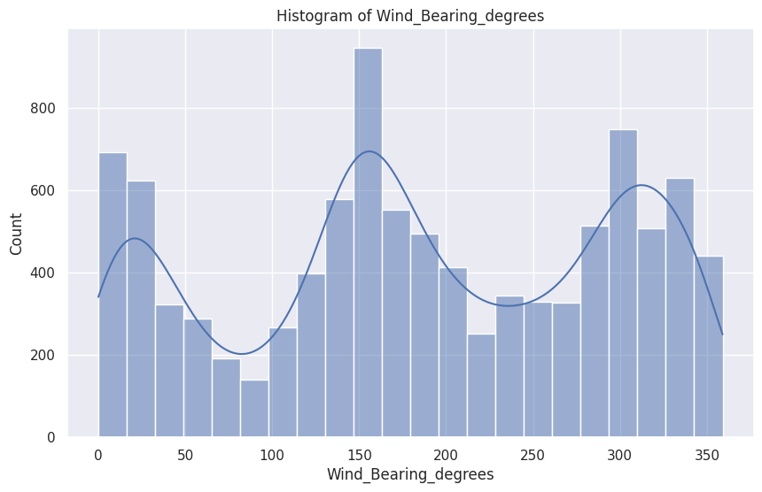

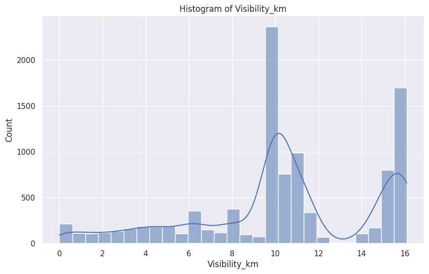

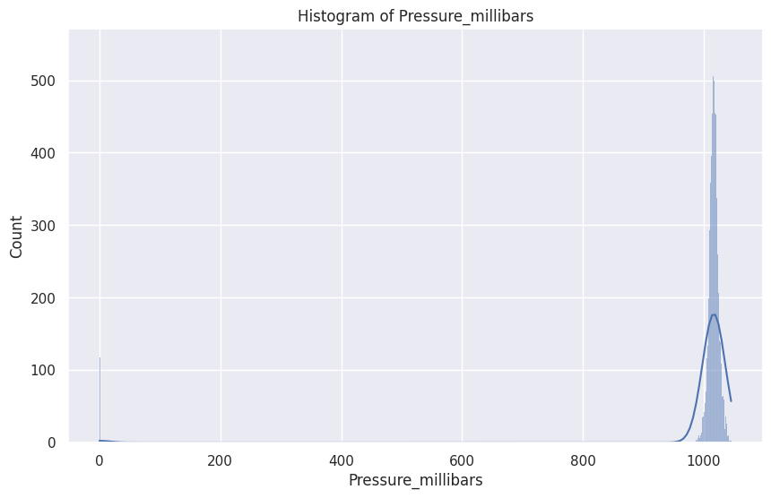

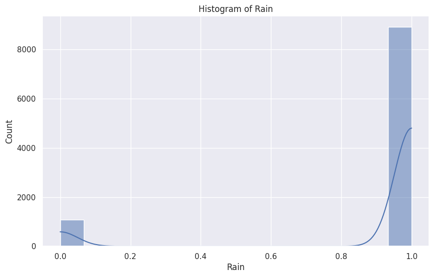

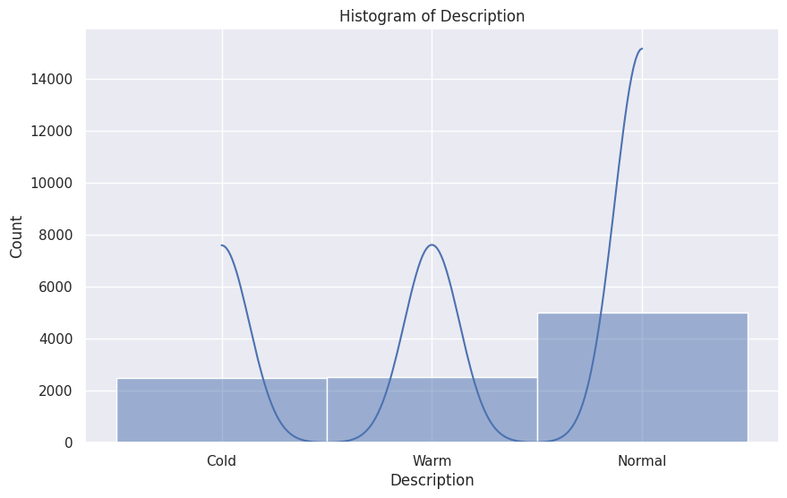

```python
# Make a histogram of all variables [ Use for loop that I showed in the video]
for column in df.columns:
    plt.figure(figsize=(10,6))
    sns.histplot(df[column], kde=True)
    plt.title(f'Histogram of {column}')
    plt.show()
```

This code provides a series of separate histograms, one for each column, displaying the distribution of values in each column, with a kernel density estimate (KDE) curve using.

1. Temperature histogram has a roughly normal distribution around 10 degree celsius.
2. The humidity histogram shows that most values are between 0.5 and 1.
3. For wind speed histogram, most values are below 30 kilometers per hour.
4. The visibility histogram shows that visibility is mostly at or above 10 kilometers.
5. The pressure histogram has a peak around 1,000. Millibars.
6. As per the rain histogram, there are more rain than no rain.
7. The description histogram indicates that the weather was mostly normal than cold or warm.

Bivariate Analysis

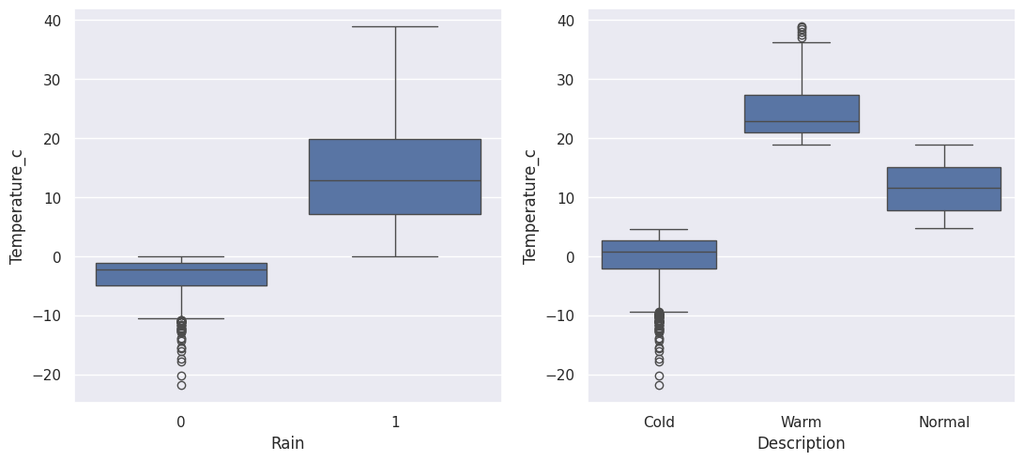

```python
# Box plot for Categorical columns
plt.figure(figsize=(20,12))
plt.subplot(2,3,1)
sns.boxplot(x = 'Rain', y = 'Temperature_c' , data = df)
plt.subplot(2,3,2)
sns.boxplot(x = 'Description' , y = 'Temperature_c' , data = df)

plt.show()
```

This code generates two box plots:

1. One for the relationship between 'Rain' and 'Temperature_c', showing the temperature **rises** when it's raining (Rain=1) vs **decreases** when it's not raining (Rain=0).
2. Another for the relationship between 'Description' (e.g., 'Cold', 'Warm', 'Normal') and 'Temperature_c', showing how temperature varies across different weather descriptions.

**Plot the scatterplots for features and the target variable `Temperature_c` and list your observations.**

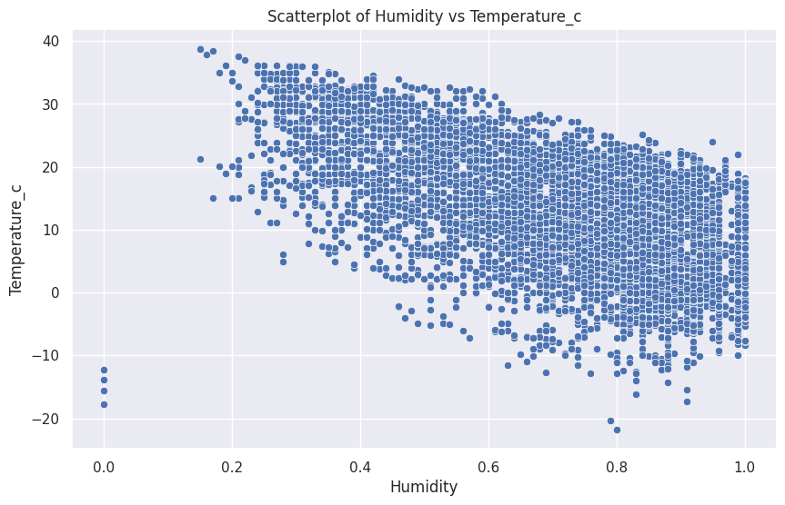

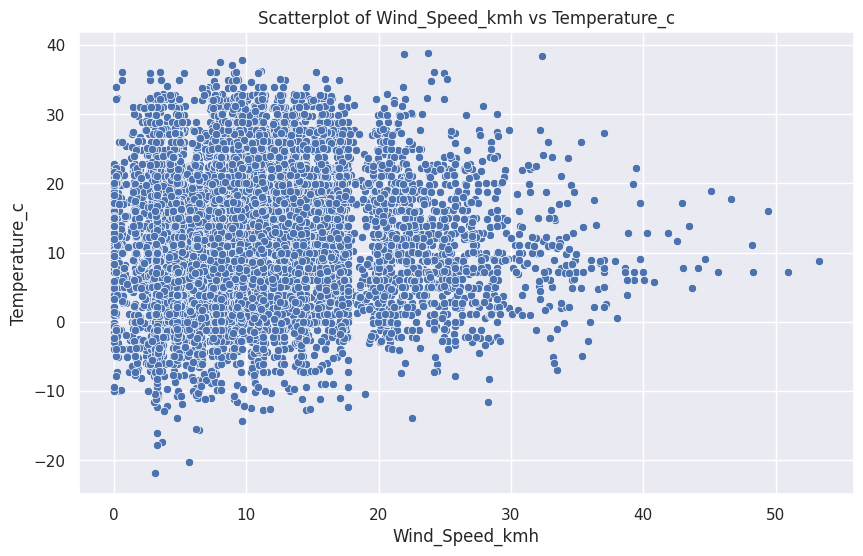

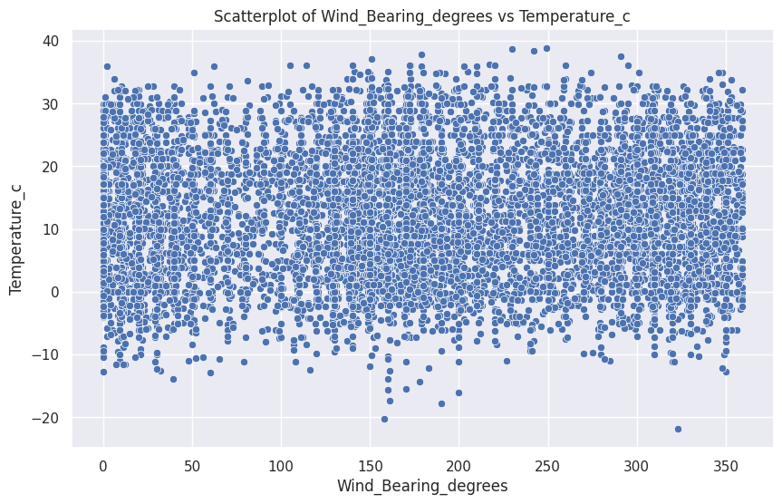

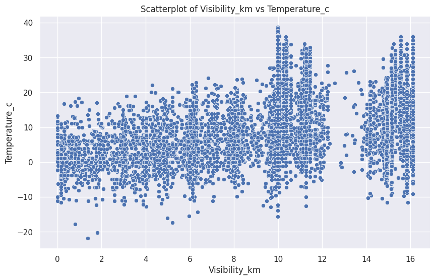

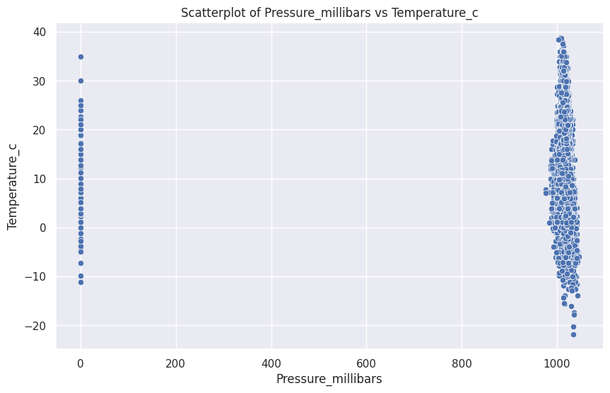

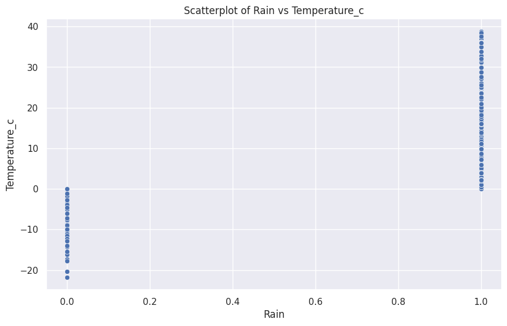

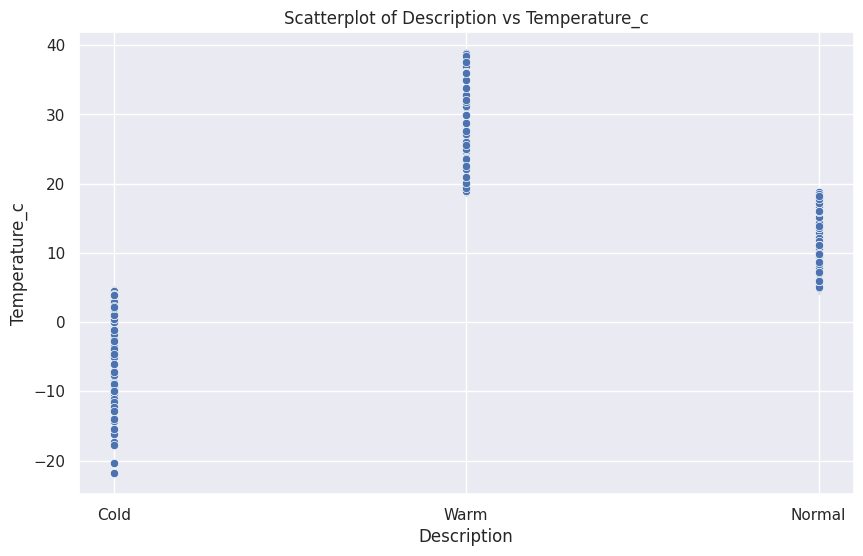

```python
# let's plot the scatterplots of Temperature with all the features [ Use for loop as shown in the video]
for column in df.columns:
    if column != 'Temperature_c':
        plt.figure(figsize=(10,6))
        sns.scatterplot(x = column, y = 'Temperature_c', data = df)
        plt.title(f'Scatterplot of {column} vs Temperature_c')
        plt.show()
```

This code generates scatterplots for each column vs 'Temperature_c' to visualize correlations and relationships between temperature and other features.

**Plot the correlation heatmap and list your observations.**

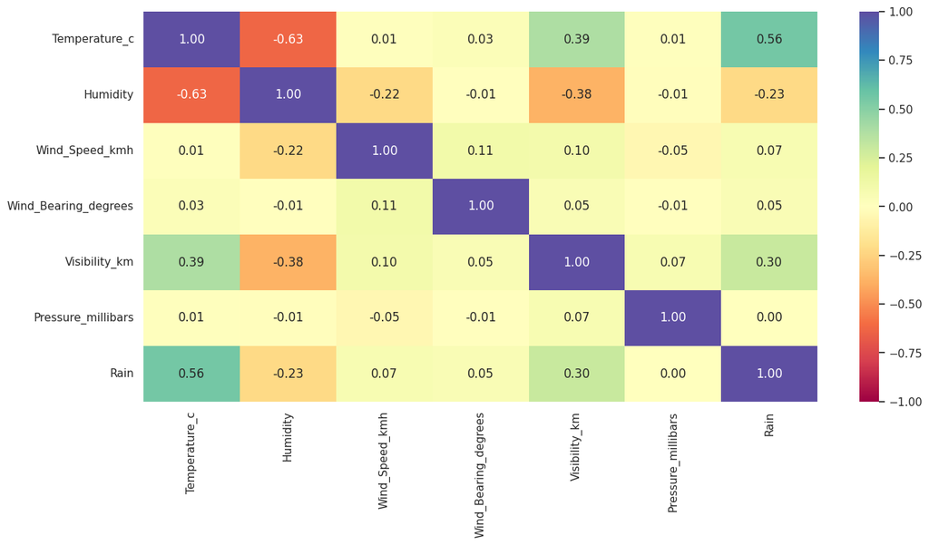

```python
# Select only numeric columns
numeric_df = df.select_dtypes(include=['int64', 'float64'])

# Plot heatmap of correlation matrix
plt.figure(figsize=(15,7))
sns.heatmap(numeric_df.corr(), annot=True, vmin=-1, vmax=1, fmt=".2f", cmap="Spectral")
plt.show()
```

This code generates a heatmap of the correlation matrix for the numeric columns in the dataframe, showing the correlation between each pair of columns. The heatmap will help identify strong positive or negative correlations between variables.

## Split the dataset & Model building

Split the data into the dependent and independent variables, create dummy variables for the categorical variables, add a constant to the independent variables, and further split it in a ratio of 70:30 for train and test sets.

```python
# Split the data into the dependent and independent variables
x = df.drop("Temperature_c", axis = 1)
y = df["Temperature_c"]
```

```python
x.info()   # Check the Data types
```

```
<class 'pandas.core.frame.DataFrame'>
RangeIndex: 10000 entries, 0 to 9999
Data columns (total 7 columns):
 #   Column                Non-Null Count  Dtype
---  ------                --------------  -----
 0   Humidity              10000 non-null  float64
 1   Wind_Speed_kmh        10000 non-null  float64
 2   Wind_Bearing_degrees  10000 non-null  int64
 3   Visibility_km         10000 non-null  float64
 4   Pressure_millibars    10000 non-null  float64
 5   Rain                  10000 non-null  int64
 6   Description           10000 non-null  object
dtypes: float64(4), int64(2), object(1)
memory usage: 547.0+ KB
```

```python
# creating dummy variables
x=pd.get_dummies(
    x,columns=x.select_dtypes(include=["object","category"]).columns.tolist(),drop_first= True,
)
x.head()
```

|  | Humidity | Wind_Speed_kmh | Wind_Bearing_degrees | Visibility_km | Pressure_millibars | Rain | Description_Normal | Description_Warm |
| --- | --- | --- | --- | --- | --- | --- | --- | --- |
| 0 | 0.92 | 11.2700 | 130 | 8.0500 | 1021.60 | 0 | False | False |
| 1 | 0.73 | 20.9300 | 330 | 16.1000 | 1017.00 | 1 | False | True |
| 2 | 0.97 | 5.9731 | 193 | 14.9086 | 1013.99 | 1 | True | False |
| 3 | 0.82 | 3.2200 | 300 | 16.1000 | 1031.59 | 1 | False | False |
| 4 | 0.60 | 10.8836 | 116 | 9.9820 | 1020.88 | 1 | False | False |

```python
# Add constant term to the dataset
x=sm.add_constant(x)
x.head()
```

|  | const | Humidity | Wind_Speed_kmh | Wind_Bearing_degrees | Visibility_km | Pressure_millibars | Rain | Description_Normal | Description_Warm |
| --- | --- | --- | --- | --- | --- | --- | --- | --- | --- |
| 0 | 1.0 | 0.92 | 11.2700 | 130 | 8.0500 | 1021.60 | 0 | False | False |
| 1 | 1.0 | 0.73 | 20.9300 | 330 | 16.1000 | 1017.00 | 1 | False | True |
| 2 | 1.0 | 0.97 | 5.9731 | 193 | 14.9086 | 1013.99 | 1 | True | False |
| 3 | 1.0 | 0.82 | 3.2200 | 300 | 16.1000 | 1031.59 | 1 | False | False |
| 4 | 1.0 | 0.60 | 10.8836 | 116 | 9.9820 | 1020.88 | 1 | False | False |

```python
# Splitting the data in 70:30 ratio for train and test data
x_train, x_test, y_train, y_test = train_test_split(x, y, test_size=0.30, random_state=1)
```

### Model Building

**Make the linear model using statsmodels OLS and print the model summary.**

```python
# Select only numeric columns
numeric_cols = x.select_dtypes(include=['int64', 'float64']).columns
x_train_numeric = x_train[numeric_cols]
x_test_numeric = x_test[numeric_cols]
y_train_numeric = y_train

# Create and fit the OLS model
model = sm.OLS(y_train_numeric, x_train_numeric)
fit_model = model.fit()
print(fit_model.summary())
```

```
                            OLS Regression Results
==============================================================================
Dep. Variable:          Temperature_c   R-squared:                       0.602
Model:                            OLS   Adj. R-squared:                  0.602
Method:                 Least Squares   F-statistic:                     1763.
Date:                Mon, 24 Mar 2025   Prob (F-statistic):               0.00
Time:                        14:43:04   Log-Likelihood:                -22471.
No. Observations:                7000   AIC:                         4.496e+04
Df Residuals:                    6993   BIC:                         4.500e+04
Df Model:                           6
Covariance Type:            nonrobust
========================================================================================
                           coef    std err          t      P>|t|      [0.025      0.975]
----------------------------------------------------------------------------------------
const                   20.3761      0.814     25.029      0.000      18.780      21.972
Humidity               -25.9297      0.405    -64.069      0.000     -26.723     -25.136
Wind_Speed_kmh          -0.2115      0.011    -19.796      0.000      -0.232      -0.191
Wind_Bearing_degrees     0.0020      0.001      2.962      0.003       0.001       0.003
Visibility_km            0.1842      0.019      9.657      0.000       0.147       0.222
Pressure_millibars      -0.0011      0.001     -1.718      0.086      -0.002       0.000
Rain                    13.0995      0.244     53.702      0.000      12.621      13.578
==============================================================================
Omnibus:                       86.783   Durbin-Watson:                   2.047
Prob(Omnibus):                  0.000   Jarque-Bera (JB):               89.857
Skew:                          -0.277   Prob(JB):                     3.08e-20
Kurtosis:                       2.960   Cond. No.                     1.21e+04
==============================================================================

Notes:
[1] Standard Errors assume that the covariance matrix of the errors is correctly specified.
[2] The condition number is large, 1.21e+04. This might indicate that there are
strong multicollinearity or other numerical problems.
```

This output shows the results of OLS regression analysis, where Temperature_c is the dependent variable and the other variables are independent.

Observations:

1. The model explains 60.2% of the variation in Temperature_c (R-squared: 0.602).
2. All variables except Pressure_millibars (0.086) are statistically significant (p-value < 0.05).
3. The negative coefficients for Humidity, Wind_Speed_kmh, and Pressure_millibars indicate that these variables have a negative impact on the dependent variable (Temperature_c). However Wind_Bearing_degrees, Visibility_km, and Rain have positive coefficients, suggesting a positive impact on Temperature_c.
4. A large condition number (1.21e+04) suggests potential multicollinearity issues in the independent variables, which could affect the stability of the coefficient estimates.

**Get the value of the coefficient of determination.**

```python
print("The coefficient of determination (R-squared) is ", fit_model.rsquared)
```

```
The coefficient of determination (R-squared) is  0.6020124169749561
```

**Get the predictions on test set**

```python
# Make predictions on the test data
y_pred = fit_model.predict(sm.add_constant(x_test_numeric))  # Use fit_model for predictions
print(y_pred)
```

```
9953    10.413684
3850     8.638761
4962    16.327555
3886    16.588167
5437    12.050391
          ...
5273    11.781160
8014    15.416488
8984    16.177900
6498    13.447208
6327    16.428770
Length: 3000, dtype: float64
```

This code uses the trained model fit_model to make predictions on the test data x_test_numeric. The sm.add_constant function is used to add a constant term to the test data, which is necessary for the model to make predictions. The predicted values are stored in y_pred.

**Observe the distribution of the errors**

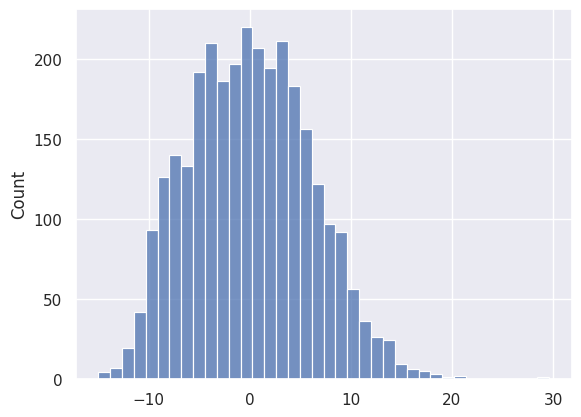

```python
error =y_pred- y_test
error
sns.histplot(error)
```

The distribution of the errors appears to be approximately normal with a peak near zero. It has a slight skew to the right with some values, extending towards 25, and very few values below -10

## Model Performance Check

Let's check the performance of the model using different metrics.

- We will be using metric functions defined in sklearn for RMSE, MAE, and $R^2$.
- We will define a function to calculate MAPE and adjusted $R^2$.
  - The mean absolute percentage error (MAPE) measures the accuracy of predictions as a percentage, and can be calculated as the average absolute percent error for each predicted value minus actual values divided by actual values. It works best if there are no extreme values in the data and none of the actual values are 0.
- We will create a function which will print out all the above metrics in one go.

```python
# function to compute adjusted R-squared
def adj_r2_score(predictors, targets, predictions):
    r2 = r2_score(targets, predictions)
    n = predictors.shape[0]
    k = predictors.shape[1]
    return 1 - ((1 - r2) * (n - 1) / (n - k - 1))


# function to compute MAPE
def mape_score(targets, predictions):
    return np.mean(np.abs(targets - predictions) / targets) * 100


# function to compute different metrics to check performance of a regression model
def model_performance_regression(model, predictors, target):
    """
    Function to compute different metrics to check regression model performance

    model: regressor
    predictors: independent variables
    target: dependent variable
    """

    # predicting using the independent variables
    pred = model.predict(predictors)

    r2 = r2_score(target, pred)  # to compute R-squared
    adjr2 = adj_r2_score(predictors, target, pred)  # to compute adjusted R-squared
    rmse = np.sqrt(mean_squared_error(target, pred))  # to compute RMSE
    mae = mean_absolute_error(target, pred)  # to compute MAE
    mape = mape_score(target, pred)  # to compute MAPE

    # creating a dataframe of metrics
    df_perf = pd.DataFrame(
        {
            "RMSE": rmse,
            "MAE": mae,
            "R-squared": r2,
            "Adj. R-squared": adjr2,
            "MAPE": mape,
        },
        index=[0],
    )

    return df_perf
```

```python
# checking model performance on train set (seen 70% data)
print("Training Performance\n")
olsmodel_test_perf = {
    'MSE': mean_squared_error(y_test, y_pred),
    'MAE': mean_absolute_error(y_test, y_pred),
    'R2': r2_score(y_test, y_pred)
}
olsmodel_test_perf
```

[output not shown]

```
{'MSE': 35.94279427186909, 'MAE': 4.9074722519701055, 'R2': 0.6040176613615407}
```

```python
# checking model performance on test set (seen 30% data)
print("Test Performance\n")
olsmodel_test_perf = model_performance_regression(fit_model, x_test_numeric, y_test)
olsmodel_test_perf
```

```
Test Performance
```

|  | RMSE | MAE | R-squared | Adj. R-squared | MAPE |
| --- | --- | --- | --- | --- | --- |
| 0 | 5.995231 | 4.907472 | 0.604018 | 0.603091 | inf |

Summary of the result:

**Note:**

- You might get MAPE value inf. This is not a wrong answer, you can leave as is.

## Conclusions:

Key insights based on the analysis of the weather dataset shows that temperature is normally distributed around 10 degree C, but it varies significantly across weather descriptions. Humidity mostly between 0.5 to 1. Wind speed is generally below 30 km/h and visibility is often at or above 10 km. Rainy days are more frequent than the dry ones.

The OLS regression model has a good fit, with humidity, wind speed, and rain being the most influential factors in predicting temperature. Humidity and Wind speed affects negatively however.The model explains about 60% of the variance in temperature. But an MSE of 35.94 and an RMSE of 5.99 suggests potential for improvement.

Recommendations

- Feature Engineering: Perform feature engineering to create new derived features that can help capture the underlying relationships more effectively.
- Model Selection: Explore advanced models like Random Forests or Gradient Boosting or neural networks that explore more non-linear relationships.
- Cross-Validation: Use k-fold cross-validation for better generalization and identify overfitting and underfitting issues better.
- Additional Features: Explore additional features if possible that may have a strong influence on temperature.